# Fatal Police Shootings in the US

## by Fares Lassoued

## Preliminary Wrangling

This [dataset](https://www.kaggle.com/kwullum/fatal-police-shootings-in-the-us) is from kaggle and it states as description: The 2014 killing of Michael Brown in Ferguson, Missouri, began the protest movement culminating in Black Lives Matter and an increased focus on police accountability nationwide. Since Jan. 1, 2015, The Washington Post has been compiling a database of every fatal shooting in the US by a police officer in the line of duty. It's difficult to find reliable data from before this period, as police killings haven't been comprehensively documented, and the statistics on police brutality are much less available. As a result, a vast number of cases go unreported. The Washington Post is tracking more than a dozen details about each killing - including the race, age and gender of the deceased, whether the person was armed, and whether the victim was experiencing a mental-health crisis. They have gathered this information from law enforcement websites, local new reports, social media, and by monitoring independent databases such as "Killed by police" and "Fatal Encounters". The Post has also conducted additional reporting in many cases. There are four additional datasets. These are US census data on poverty rate, high school graduation rate, median household income, and racial demographics.

The dataset comes into 5 different files : `PoliceKillings.csv` and we will use other csv files to depict relationships and answer specific questions.

we will start by looking at the age of victims.

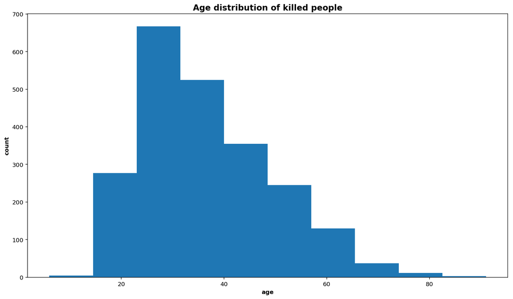

```python
plt.figure(figsize=[14.70, 8.27])
plt.hist(police_killings.age)
plt.xlabel('age',fontsize = 10, weight = "bold")
plt.ylabel('count',fontsize = 10, weight = "bold")
plt.title('Age distribution of killed people',fontsize = 14, weight = "bold")
plt.show()
```

Age distribution is right skewed with a peak between 20 and 40.

Next we will plot number of deaths per month

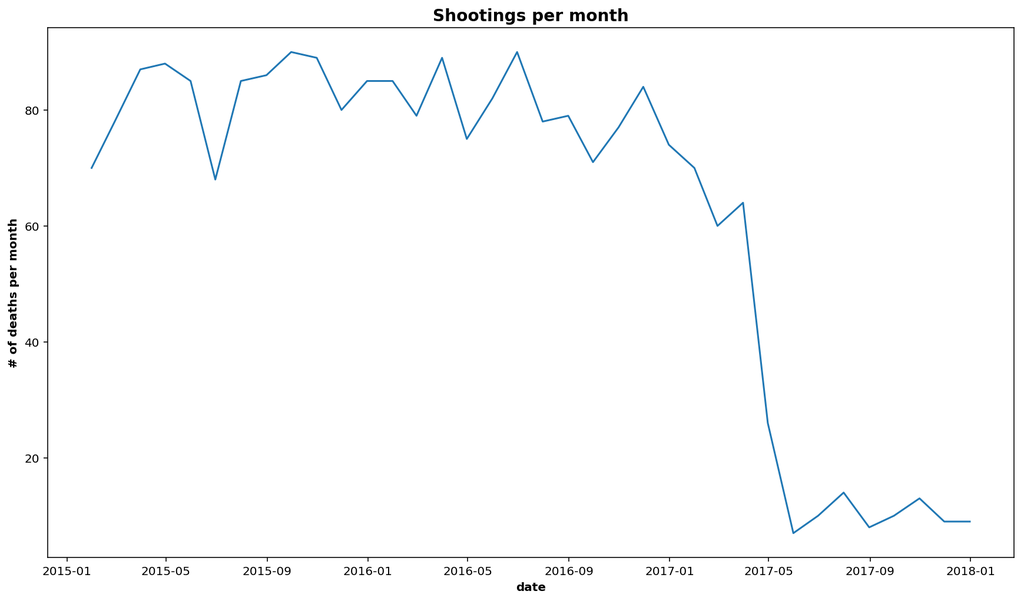

```python
plt.figure(figsize=[14.70, 8.27])
dates = police_killings.set_index('date').groupby(pd.Grouper(freq='M'))['id'].count()
sb.lineplot(data=dates)

plt.xlabel('date',fontsize = 10, weight = "bold")
plt.ylabel('# of deaths per month',fontsize = 10, weight = "bold")
plt.title('Shootings per month',fontsize = 14, weight = "bold")
plt.xticks();
```

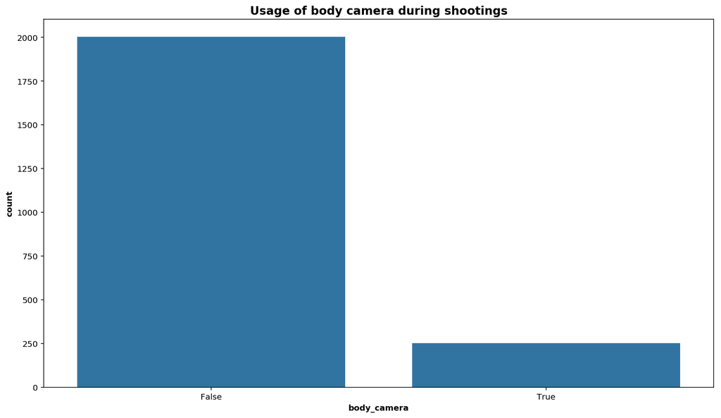

```python
#body_cam

plt.figure(figsize=[14.70, 8.27])
sb.countplot(data=police_killings, x='body_camera', color=uni_color)
plt.title('Usage of body camera during shootings',fontsize = 14, weight = "bold");

plt.xlabel('body_camera',fontsize = 10, weight = "bold")
plt.ylabel('count',fontsize = 10, weight = "bold");
```

In most killings there was no body camera.

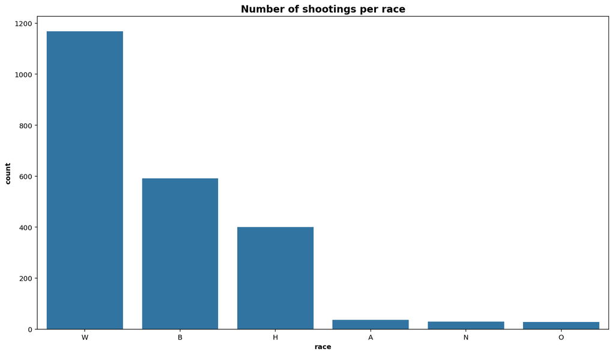

```python
plt.figure(figsize=[14.70, 8.27])
sb.countplot(data=police_killings, x='race', color=uni_color, order=police_killings.race.value_counts().index)
plt.title('Number of shootings per race',fontsize = 14, weight = "bold");

plt.xlabel('race',fontsize = 10, weight = "bold")
plt.ylabel('count',fontsize = 10, weight = "bold");
```

ordered from highest to lowest counts, people with white race are the most killed in this data, followed by black as the 2nd most killed, then comes hispanic race in third place and finally Asian, Native american and other with small counts. However, we should remake this plot with each race's proportion of the whole data to be fair.

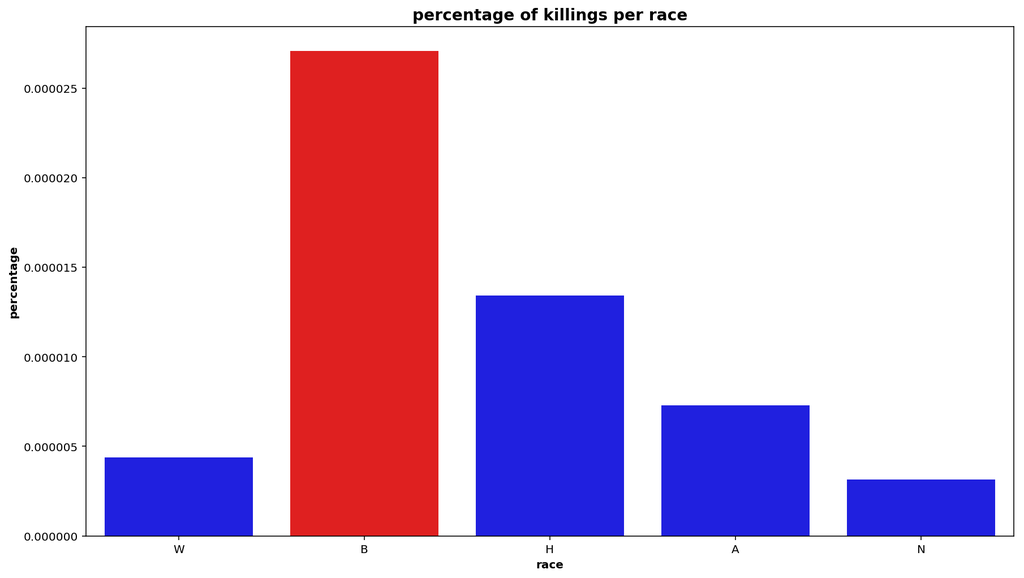

```python
plt.figure(figsize=[14.70, 8.27])

clrs = ['blue' if (x < max(killings_per_race_count.values)) else 'red' for x in killings_per_race_count.values ]
sb.barplot(x=killings_per_race_count.index, y=killings_per_race_count.values, palette=clrs)
plt.title('percentage of killings per race',fontsize = 14, weight = "bold");

plt.xlabel('race',fontsize = 10, weight = "bold")
plt.ylabel('percentage',fontsize = 10, weight = "bold");
```

The modification of the previous plot made by dividing the number of kills per race proportion shows that black people are the most killed during this period, next comes hispanic while white is the 2nd least in the list as opposed to what the previous plot has conveyed.

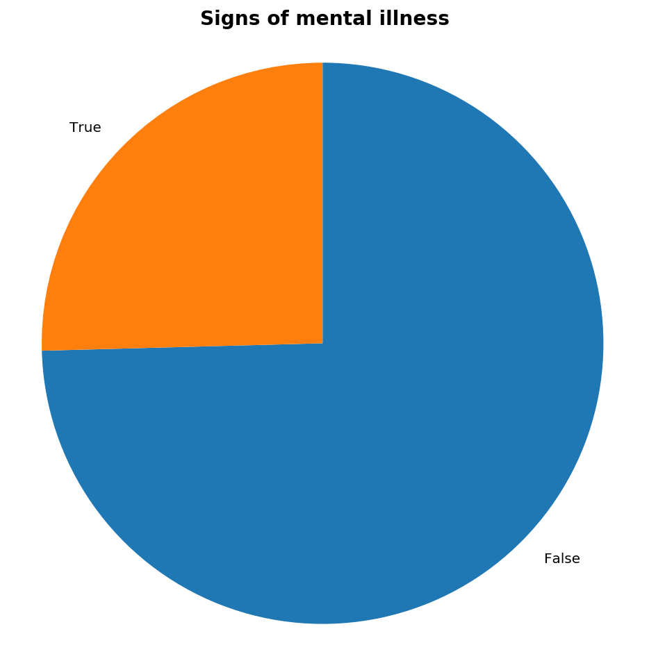

```python
plt.figure(figsize=[14.70, 8.27])

sorted_counts = police_killings['signs_of_mental_illness'].value_counts()
plt.pie(sorted_counts, labels = sorted_counts.index, startangle = 90,
        counterclock = False);
plt.axis('square')
plt.title('Signs of mental illness',fontsize = 14, weight = "bold")
plt.show()
```

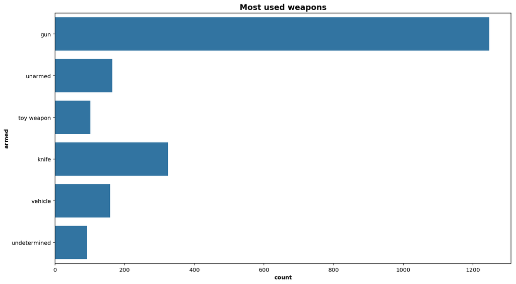

```python
plt.figure(figsize=[14.70, 8.27])
most_used = police_killings.armed.value_counts()>50
sb.countplot(data=police_killings.loc[police_killings.armed.isin(most_used[most_used].index.tolist())],
             y='armed', color=uni_color)
plt.title('Most used weapons',fontsize = 14, weight = "bold")
plt.xlabel('count',fontsize = 10, weight = "bold")
plt.ylabel('armed',fontsize = 10, weight = "bold");
```

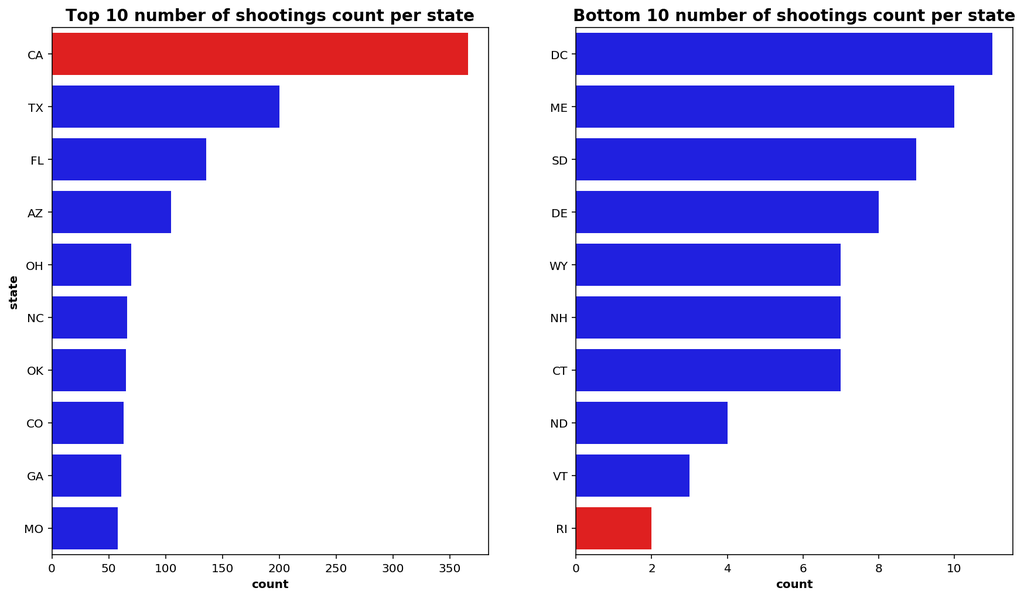

```python
plt.figure(figsize=[14.70, 8.27])

plt.subplot(121)
clrs_top = ['blue' if (x < max(police_killings.state.value_counts().values)) else 'red' for x in police_killings.state.value_counts().values ]
sb.countplot(data=police_killings, y='state', palette=clrs_top[:10], order=police_killings.state.value_counts().index[:10])
plt.title('Top 10 number of shootings count per state',fontsize = 14, weight = "bold")
plt.xlabel('count',fontsize = 10, weight = "bold")
plt.ylabel('state',fontsize = 10, weight = "bold");

plt.subplot(122)
clrs_bottom = ['blue' if (x > min(police_killings.state.value_counts().values)) else 'red' for x in police_killings.state.value_counts().values ]
sb.countplot(data=police_killings, y='state', palette=clrs_bottom[-10:], order=police_killings.state.value_counts().index[-10:])
plt.title('Bottom 10 number of shootings count per state',fontsize = 14, weight = "bold")
plt.xlabel('count',fontsize = 10, weight = "bold")
plt.ylabel('',fontsize = 10, weight = "bold");
```

California is the state where most killings took place while Rhode Island is the one with least killings.

N.B: We will compare the mentioned states given that they have a huge difference in population (CA:39 million vs. RI: 1.1 million)

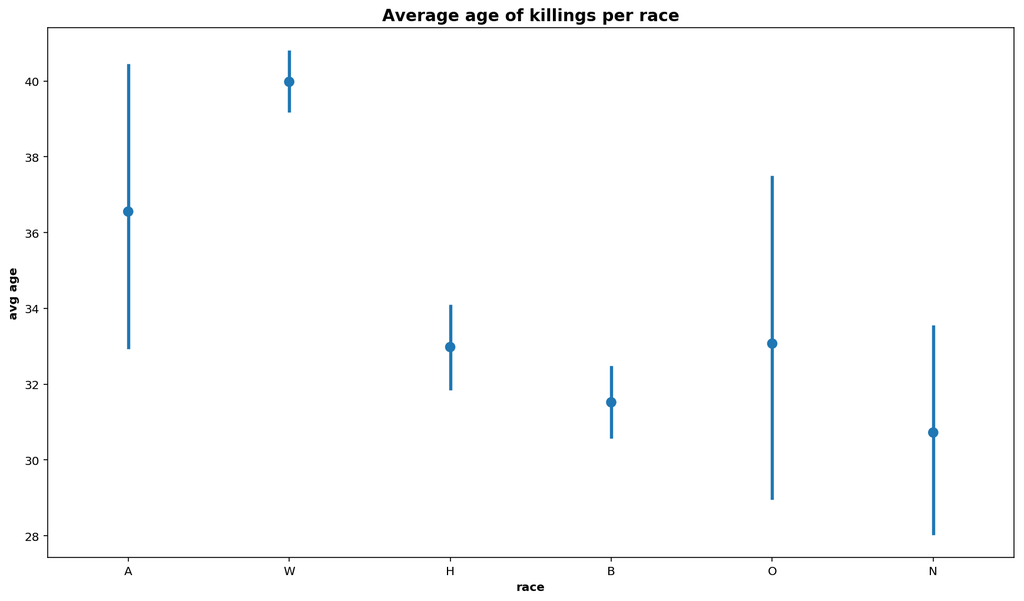

```python
#age vs. race
plt.figure(figsize=[14.70, 8.27])
sb.pointplot(data = police_killings, x = 'race', y = 'age', color = uni_color, linestyles='')
plt.title('Average age of killings per race',fontsize = 14, weight = "bold")
plt.xlabel('race',fontsize = 10, weight = "bold")
plt.ylabel('avg age',fontsize = 10, weight = "bold");
```

this plot gives a shows clearly the avg age of different races and it depicts for example that white race avg age is around 40 whilst black is around 32.

let's plot age against signs of mentall illness

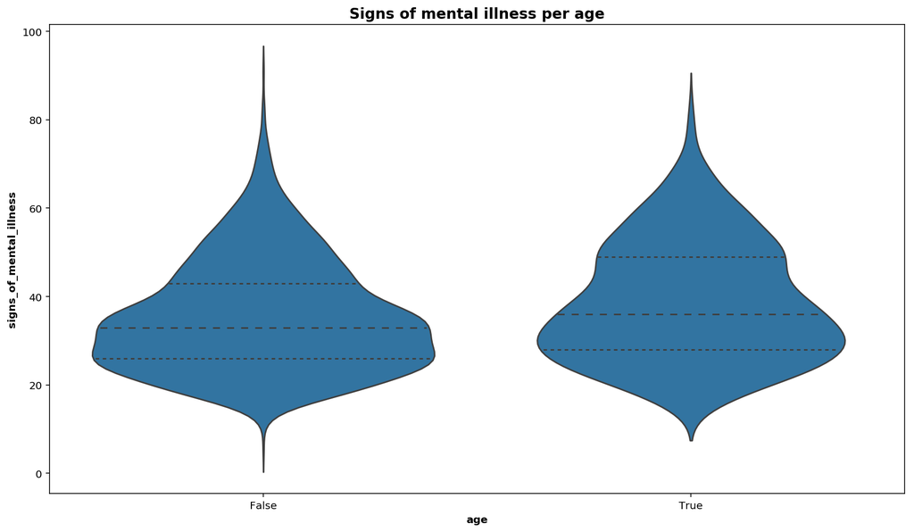

```python
#age vs. signs_of_mental_illness
plt.figure(figsize=[14.70, 8.27])
sb.violinplot(data = police_killings, x = 'signs_of_mental_illness', y = 'age', color = uni_color, inner='quartile')
plt.title('Signs of mental illness per age',fontsize = 14, weight = "bold")
plt.xlabel('age',fontsize = 10, weight = "bold")
plt.ylabel('signs_of_mental_illness',fontsize = 10, weight = "bold");
```

signs of mental illness appear more frequently within 30s while the distribution of ages above 50 are more larger for people showing signs of mental illness.

Now let's compare the states we mentioned earlier: Carlifornia Vs. Rhode Island

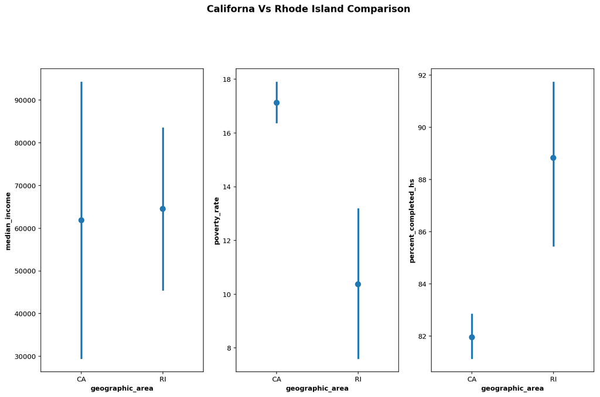

```python
#median_house_income/percentage_below_poverty_level
plt.figure(figsize=[14.70, 8.27])

state_income = median_house_income.loc[median_house_income.geographic_area.isin(['CA','RI'])]
state_poverty_lvl = percentage_below_poverty_level.loc[percentage_below_poverty_level.geographic_area.isin(['CA','RI'])]
state_comp = percent_over25_comp_highschool.loc[percent_over25_comp_highschool.geographic_area.isin(['CA','RI'])]

plt.subplot(131)
sb.pointplot(data=state_income,x='geographic_area', y='median_income',color = uni_color, linestyles='', ci='sd')
plt.xlabel('geographic_area',fontsize = 10, weight = "bold")
plt.ylabel('median_income',fontsize = 10, weight = "bold")

plt.subplot(132)
sb.pointplot(data=state_poverty_lvl,x='geographic_area', y='poverty_rate',color = uni_color, linestyles='',)
plt.xlabel('geographic_area',fontsize = 10, weight = "bold")
plt.ylabel('poverty_rate',fontsize = 10, weight = "bold")

plt.subplot(133)
sb.pointplot(data=state_comp,x='geographic_area', y='percent_completed_hs',color = uni_color, linestyles='')
plt.xlabel('geographic_area',fontsize = 10, weight = "bold")
plt.ylabel('percent_completed_hs',fontsize = 10, weight = "bold")

plt.suptitle('Californa Vs Rhode Island Comparison',y = 1.04,fontsize = 14, weight = "bold");
```

In 2015, Rhode Island cities has on average higher median_house_income and with less standard deviation than cities of California.In addition, poverty rate in RI cities is much lower that CA cities. On average, percentage of people over the age of 25 that completed high school in RI (around 88%) cities is higher than CA (around 82%)

Next we will look into weapon (among the most used weapons only) usage per state

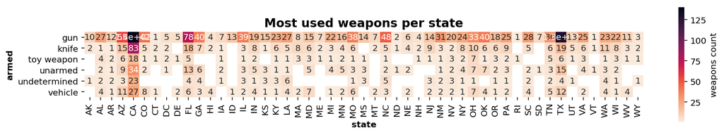

```python
#https://stackoverflow.com/questions/45122416/one-horizontal-colorbar-for-seaborn-heatmaps-subplots-and-annot-issue-with-xtick
plt.figure(figsize=[14.70, 8.27])

cat_means = police_killings.loc[police_killings.armed.isin(most_used[most_used].index.tolist())].groupby(['state', 'armed']).count()['id']
cat_means = cat_means.reset_index(name = 'count')
cat_means = cat_means.pivot(index = 'armed', columns = 'state',
                            values = 'count')
sb.heatmap(cat_means,cbar_kws={'orientation': 'vertical', 'label' : 'weapons count', "shrink": .30},annot=True,cmap=sb.cm.rocket_r, square=True)

plt.title('Most used weapons per state',fontsize = 14, weight = "bold" )
plt.xlabel('state',fontsize = 10, weight = "bold" )
plt.ylabel('armed',fontsize = 10, weight = "bold" );
```

We already know that gun is the most used weapon but now we can spot which states used gun the most like California (CA), Texas(TX), and states with medium gun usage like Arizona(AZ),New York(NY),et... and other states with low weapon usage like Rhode Island (RI), Vermont(VT),etc... . However, these observations are from this dataset only and we did not take each states population or number of existing guns etc...

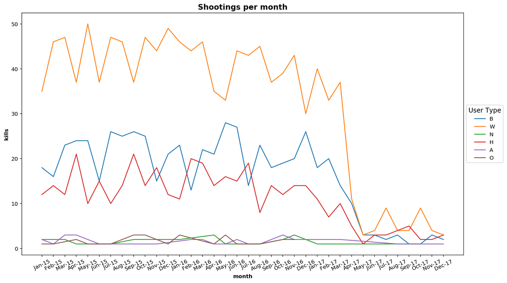

```python
#https://stackoverflow.com/questions/25146121/extracting-just-month-and-year-separately-from-pandas-datetime-column

police_killings['year-month'] = police_killings.date.apply(lambda x: x.strftime('%b-%y'))

#aggregate(count) by race and year-month date
data = police_killings.groupby(['race','year-month'])['id'].agg('count').reset_index().rename(columns={'id':'count'}).sort_values(by='year-month')

#custom dict to sort string dates
custom_dict = {x:i for i,x in enumerate(police_killings.sort_values(by='date')['year-month'].unique())}



plt.figure(figsize=[14.70, 8.27])

df = data[data['race'] == 'B']
sb.lineplot(data=df.iloc[df['year-month'].map(custom_dict).argsort()] , x='year-month', y='count', sort=False)

df = data[data['race'] == 'W']
sb.lineplot(data=df.iloc[df['year-month'].map(custom_dict).argsort()], x='year-month', y='count', sort=False)

df = data[data['race'] == 'N']
sb.lineplot(data=df.iloc[df['year-month'].map(custom_dict).argsort()], x='year-month', y='count', sort=False)

df = data[data['race'] == 'H']
sb.lineplot(data=df.iloc[df['year-month'].map(custom_dict).argsort()], x='year-month', y='count', sort=False)

df = data[data['race'] == 'A']
sb.lineplot(data=df.iloc[df['year-month'].map(custom_dict).argsort()], x='year-month', y='count', sort=False)

df = data[data['race'] == 'O']
sb.lineplot(data=df.iloc[df['year-month'].map(custom_dict).argsort()], x='year-month', y='count', sort=False)



plt.xticks(rotation=25)



plt.legend(['B','W','N','H','A','O'],loc='center left', bbox_to_anchor=(1, 0.5),
           title="User Type", title_fontsize = 12)
plt.title('Shootings per month',fontsize = 14, weight = "bold" )
plt.xlabel('month',fontsize = 10, weight = "bold" )
plt.ylabel('kills',fontsize = 10, weight = "bold" );
```

We can see that the time pattern of kills for white, black and hispanic is not similair but they share in common the same period of fluctuation which is 2 months.